# Qualitative Activity Recognition of Weight Lifting Exercises

Oleg Kufirin

17/02/2021

## Project objectives

One thing that people regularly do is quantify how much of a particular activity they do, but they rarely quantify how well they do it. In this project, our goal will be to use data from accelerometers on the belt, forearm, arm, and dumbell of 6 participants.

The goal of this project is to predict the manner in which they did the exercise. This is the “classe” variable in the training set.

## Background

Using devices such as Jawbone Up, Nike FuelBand, and Fitbit it is now possible to collect a large amount of data about personal activity relatively inexpensively. These type of devices are part of the quantified self movement – a group of enthusiasts who take measurements about themselves regularly to improve their health, to find patterns in their behavior, or because they are tech geeks. One thing that people regularly do is quantify how much of a particular activity they do, but they rarely quantify how well they do it. In this project, your goal will be to use data from accelerometers on the belt, forearm, arm, and dumbell of 6 participants. They were asked to perform barbell lifts correctly and incorrectly in 5 different ways. More information is available from the website here: http://web.archive.org/web/20161224072740/http:/groupware.les.inf.puc-rio.br/har (see the section on the Weight Lifting Exercise Dataset).

## System setup and libraries

```r
setwd("D:/Data Science Specialisation/Practical Machine Learning/4/Course Project/")
library(caret)
library(xlsx)
```

## Getting the data

First, we will download the datasets.

```r
download.file("https://d396qusza40orc.cloudfront.net/predmachlearn/pml-training.csv", "training.csv")
download.file("https://d396qusza40orc.cloudfront.net/predmachlearn/pml-testing.csv", "test.csv")
```

Then, load the datasets into R treating empty values as NA.

```r
training_org <- read.csv("training.csv", header = T, na.strings = c("", "NA"))
test_org<- read.csv("test.csv", header = T, na.strings = c("", "NA"))
```

Checking dimensions of the datasets and names of the variables.

```r
dim(training_org)
```

```
## [1] 19622   160
```

```r
dim(test_org)
```

```
## [1]  20 160
```

```r
names(training_org)
```

```
##   [1] "X"                        "user_name"
##   [3] "raw_timestamp_part_1"     "raw_timestamp_part_2"
##   [5] "cvtd_timestamp"           "new_window"
##   [7] "num_window"               "roll_belt"
##   [9] "pitch_belt"               "yaw_belt"
##  [11] "total_accel_belt"         "kurtosis_roll_belt"
##  [13] "kurtosis_picth_belt"      "kurtosis_yaw_belt"
##  [15] "skewness_roll_belt"       "skewness_roll_belt.1"
##  [17] "skewness_yaw_belt"        "max_roll_belt"
##  [19] "max_picth_belt"           "max_yaw_belt"
##  [21] "min_roll_belt"            "min_pitch_belt"
##  [23] "min_yaw_belt"             "amplitude_roll_belt"
##  [25] "amplitude_pitch_belt"     "amplitude_yaw_belt"
##  [27] "var_total_accel_belt"     "avg_roll_belt"
##  [29] "stddev_roll_belt"         "var_roll_belt"
```

[output cut: 65 more lines]

As it can be seen the datasets have significant number of input parameters - 159. The last column is the outcome varaible.

## Exploring and cleaning the data

Now, we have a look at all possible values of the outcome varaible and assess whether the dataset is balanced or not.

```r
round(table(training_org$classe) / dim(training_org)[1] * 100, 2)
```

```
##
##     A     B     C     D     E
## 28.44 19.35 17.44 16.39 18.38
```

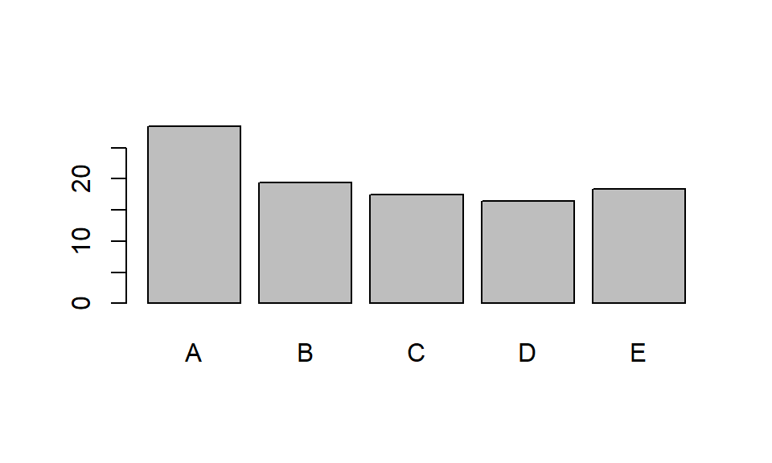

```r
barplot(round(table(training_org$classe) / dim(training_org)[1] * 100, 2))
```

There are 5 possible classes and the dataset seems reasonably balanced.

Checking the number of NAs for each column.

```r
table(colSums(is.na(training_org)))
```

```
##
##     0 19216
##    60   100
```

All columns have either 0 or 19216 NAs. The latter seems to be a significant proportion of missing values (98%), hence 100 columns can be excluded from the dataset.

Extract column names with NAs and exclude them from the training and the test sets.

```r
NA_cols <- colnames(training_org)[colSums(is.na(training_org)) > 0]
training <- training_org[, !(names(training_org) %in% NA_cols)]
test <- test_org[, !(names(test_org) %in% NA_cols)]
```

Check names of the remaining columns.

```r
colnames(training)
```

```
##  [1] "X"                    "user_name"            "raw_timestamp_part_1"
##  [4] "raw_timestamp_part_2" "cvtd_timestamp"       "new_window"
##  [7] "num_window"           "roll_belt"            "pitch_belt"
## [10] "yaw_belt"             "total_accel_belt"     "gyros_belt_x"
## [13] "gyros_belt_y"         "gyros_belt_z"         "accel_belt_x"
## [16] "accel_belt_y"         "accel_belt_z"         "magnet_belt_x"
## [19] "magnet_belt_y"        "magnet_belt_z"        "roll_arm"
## [22] "pitch_arm"            "yaw_arm"              "total_accel_arm"
## [25] "gyros_arm_x"          "gyros_arm_y"          "gyros_arm_z"
## [28] "accel_arm_x"          "accel_arm_y"          "accel_arm_z"
## [31] "magnet_arm_x"         "magnet_arm_y"         "magnet_arm_z"
## [34] "roll_dumbbell"        "pitch_dumbbell"       "yaw_dumbbell"
## [37] "total_accel_dumbbell" "gyros_dumbbell_x"     "gyros_dumbbell_y"
## [40] "gyros_dumbbell_z"     "accel_dumbbell_x"     "accel_dumbbell_y"
## [43] "accel_dumbbell_z"     "magnet_dumbbell_x"    "magnet_dumbbell_y"
## [46] "magnet_dumbbell_z"    "roll_forearm"         "pitch_forearm"
## [49] "yaw_forearm"          "total_accel_forearm"  "gyros_forearm_x"
## [52] "gyros_forearm_y"      "gyros_forearm_z"      "accel_forearm_x"
## [55] "accel_forearm_y"      "accel_forearm_z"      "magnet_forearm_x"
## [58] "magnet_forearm_y"     "magnet_forearm_z"     "classe"
```

If we look closely at the first 7 variables, we will see that they are metadata and time-stamps.

```r
head(training[, 1:7])
```

```
##   X user_name raw_timestamp_part_1 raw_timestamp_part_2   cvtd_timestamp
## 1 1  carlitos           1323084231               788290 05/12/2011 11:23
## 2 2  carlitos           1323084231               808298 05/12/2011 11:23
## 3 3  carlitos           1323084231               820366 05/12/2011 11:23
## 4 4  carlitos           1323084232               120339 05/12/2011 11:23
## 5 5  carlitos           1323084232               196328 05/12/2011 11:23
## 6 6  carlitos           1323084232               304277 05/12/2011 11:23
##   new_window num_window
## 1         no         11
## 2         no         11
## 3         no         11
## 4         no         12
## 5         no         12
## 6         no         12
```

The first column is an observation number. The second column is a user name (person who did the exercises). Columns 3 to 5 are time and date stamps. Columns 6 and 7 represent information about windows of readings. From common sense knowledge they have no relation to quality of performing exercise at particular point in time, unless a specific research hypothesis is tested (i.e. how time of the day affects quality of exercises). Hence, in this project we assume that only readings from the sensors and their derivations will be used to build a predictive model.

Following the logic above we will remove the first 7 columns.

```r
redundant_cols <- colnames(training)[1:7]
training <- training[, !(names(training) %in% redundant_cols)]
test <- test[, !(names(test) %in% redundant_cols)]
```

Convert the outcome to a factor varaible

```r
training$classe <- as.factor(training$classe)
str(training$classe)
```

```
##  Factor w/ 5 levels "A","B","C","D",..: 1 1 1 1 1 1 1 1 1 1 ...
```

Now we have datasets of the following dimensions.

```r
dim(training)
```

```
## [1] 19622    53
```

```r
dim(test)
```

```
## [1] 20 53
```

We can also check the correlation matrix, but since the number of parameters is large it is better to write it out to an Excel file.

```r
correlationMatrix <- cor(training[,1:length(training)-1])
write.xlsx(correlationMatrix, "correlationMatrix.xlsx", sheetName = "Corr", col.names = T, row.names = T, append = F)
```

## Building predictive models

### Rationale

The number of predictors in the dataset is quite large, so some techniques to reduce the number of dimensions can be applied. When training we will use different combinations of filtering out highly correlated variables (by varying cutoff parameter) and principal component analysis (by varying thresh parameter representing retained variance). Both can specified in **train** function from **caret** library.

In all training scenarios the data will be scaled, centred and checked for near-zero varaince.

```r
set.seed(7)
```

### Penalized Multinomial Regression

```r
trControl <- trainControl(method = "cv", number = 5)
system.time(multinomReg_model <- train(classe ~ .,
                                        trControl = trControl,
                                        preProcess = c("center", "scale", "nzv"),
                                        method = "multinom",
                                        data = training, trace = FALSE))
```

| Correlation, cutoff= | PCA, thresh= | Accuracy | Training Time, sec |
| --- | --- | --- | --- |
| - | - | **0.7300** | 170.19 |
| 0.75 | 0.9 | 0.5004 | 114.90 |
| - | 0.95 | 0.5329 | 132.92 |
| - | 0.8 | 0.4762 | 86.72 |
| 0.9 | - | 0.7016 | 149.28 |
| 0.75 | - | 0.5908 | 127.81 |
| 0.5 | - | 0.4999 | 110.90 |

This method showed moderate Accuracy of 0.73 with moderate training time 170 sec..

### kNN

```r
trControl <- trainControl(method = "cv", number = 5)
system.time(knn_model <- train(classe ~ .,
                                trControl = trControl,
                                preProcess = c("center", "scale", "nzv"),
                                method = "knn",
                                tuneGrid = expand.grid(k = 1:1),
                                data = training))
```

| Correlation, cutoff= | PCA, thresh= | Accuracy | Training Time, sec |
| --- | --- | --- | --- |
| - | - | **0.9925** | 49.30 |
| 0.75 | 0.9 | 0.9886 | 19.19 |
| - | 0.95 | 0.9892 | 24.17 |
| - | 0.8 | 0.9810 | 17.40 |
| 0.9 | - | 0.9912 | 41.16 |
| 0.75 | - | 0.9886 | 27.45 |
| 0.5 | - | 0.9835 | 19.83 |

Experiments showed that kNN algorithm works best with tuning parameter k=1 (not shown here). This method has very high Accuracy of 0.9925 with reasonably fast training time 49.30 sec..

### CART

```r
trControl <- trainControl(method = "cv", number = 5,
                          preProcOptions = list(cutoff = 0.5, thresh = 0.8))
system.time(cart_model <- train(classe ~ .,
                                trControl = trControl,
                                preProcess = c("center", "scale", "nzv"),
                                method = "rpart",
                                data = training))
```

| Correlation, cutoff= | PCA, thresh= | Accuracy | Training Time, sec |
| --- | --- | --- | --- |
| - | - | **0.5042** | 14.98 |
| 0.75 | 0.9 | 0.3344 | 17.61 |
| - | 0.95 | 0.3933 | 20.04 |
| - | 0.8 | 0.3632 | 18.55 |
| 0.9 | - | 0.4732 | 19.22 |
| 0.75 | - | 0.5033 | 17.20 |
| 0.5 | - | 0.4638 | 19.17 |

This method showed fast training time, but poor performance in terms of accuracy.

### Bagged CART

```r
trControl <- trainControl(method = "cv", number = 5,
                          preProcOptions = list(cutoff = 0.9))
system.time(baggedCART_model <- train(classe ~ .,
                                trControl = trControl,
                                preProcess = c("center", "scale", "nzv", "corr"),
                                method = "treebag",
                                data = training))
```

| Correlation, cutoff= | PCA, thresh= | Accuracy | Training Time, sec |
| --- | --- | --- | --- |
| - | - | 0.9871 | 99.34 |
| 0.75 | 0.9 | 0.9509 | 59.69 |
| - | 0.95 | 0.9633 | 73.15 |
| - | 0.8 | 0.9459 | 46.94 |
| 0.9 | - | **0.9881** | 92.61 |
| 0.75 | - | 0.9800 | 65.89 |
| 0.5 | - | 0.9604 | 27.84 |

### Random Forest

```r
trControl <- trainControl(method = "cv", number = 5)
system.time(rf_model <- train(classe ~ .,
                                trControl = trControl,
                                preProcess = c("center", "scale", "nzv"),
                                method = "rf",
                                tuneGrid = expand.grid(mtry = 1:1),
                                data = training))
```

| Correlation, cutoff= | PCA, thresh= | Accuracy | Training Time, sec |
| --- | --- | --- | --- |
| - | - | **0.9909** | 306.75 |
| 0.75 | 0.9 | 0.9728 | 132.52 |
| - | 0.95 | 0.9772 | 183.72 |
| - | 0.8 | 0.9635 | 93.36 |
| 0.9 | - | 0.9900 | 265.90 |
| 0.75 | - | 0.9891 | 191.56 |
| 0.5 | - | 0.9789 | 139.48 |

This method showed very high Accuracy comparable with kNN but the training time was much larger.

### Parallel Random Forest

```r
trControl <- trainControl(method = "cv", number = 5)
system.time(parRF_model <- train(classe ~ .,
                                 trControl = trControl,
                                 preProcess = c("center", "scale", "nzv"),
                                 method = "parRF",
                                 data = training))
```

| Correlation, cutoff= | PCA, thresh= | Accuracy | Training Time, sec |
| --- | --- | --- | --- |
| - | - | **0.9944** | 1126.83 |
| - | 0.8 | 0.9666 | 321.48 |
| 0.9 | - | 0.9932 | 1101.12 |
| 0.75 | - | 0.9930 | 658.35 |
| 0.2 | - | 0.9387 | 224.54 |

This method is slightly superior to kNN but had significantly larger training time.

### High Dimensional Discriminant Analysis

```r
trControl <- trainControl(method = "cv", number = 5,
                          preProcOptions = list(cutoff = 0.85,))
system.time(hdda_model <- train(classe ~ .,
                                trControl = trControl,
                                preProcess = c("center", "scale", "nzv", "corr"),
                                method = "hdda",
                                data = training))
```

| Correlation, cutoff= | PCA, thresh= | Accuracy | Training Time, sec |
| --- | --- | --- | --- |
| - | - | 0.7264 | 30.06 |
| 0.75 | 0.9 | 0.6659 | 29.56 |
| - | 0.95 | 0.6825 | 33.14 |
| - | 0.8 | 0.5704 | 31.52 |
| 0.95 | - | 0.7572 | 31.69 |
| 0.9 | - | 0.7829 | 30.33 |
| 0.85 | - | **0.7872** | 29.96 |
| 0.8 | - | 0.7824 | 30.19 |
| 0.75 | - | 0.7377 | 27.85 |
| 0.5 | - | 0.6886 | 26.75 |

This method showed very fast training time but moderate Accuracy.

### Naive Bayes

```r
trControl <- trainControl(method = "cv", number = 5,
                          preProcOptions = list(cutoff = 0.9))
system.time(nb_model <- train(classe ~ .,
                                trControl = trControl,
                                preProcess = c("center", "scale", "nzv", "corr"),
                                method = "nb",
                                data = training))
```

| Correlation, cutoff= | PCA, thresh= | Accuracy | Training Time, sec |
| --- | --- | --- | --- |
| - | - | 0.7441 | 205.85 |
| 0.75 | 0.9 | 0.6079 | 92.22 |
| - | 0.95 | 0.6442 | 114.59 |
| - | 0.8 | 0.5590 | 72.03 |
| 0.95 | - | 0.7515 | 209.41 |
| 0.9 | - | **0.7569** | 173.68 |
| 0.75 | - | 0.7389 | 135.23 |
| 0.5 | - | 0.6694 | 101.38 |
| 0.2 | - | 0.5234 | 49.91 |

This method showed moderate Accuracy and moderate training time.

### Linear Discriminant Analysis

```r
trControl <- trainControl(method = "cv", number = 5)
system.time(lda_model <- train(classe ~ .,
                              trControl = trControl,
                              preProcess = c("center", "scale", "nzv"),
                              method = "lda",
                              data = training))
```

| Correlation, cutoff= | PCA, thresh= | Accuracy | Training Time, sec |
| --- | --- | --- | --- |
| - | - | **0.7018** | 11.78 |
| 0.75 | 0.9 | 0.5188 | 11.59 |
| - | 0.95 | 0.5272 | 11.81 |
| - | 0.8 | 0.4673 | 12.11 |
| 0.95 | - | 0.6852 | 12.77 |
| 0.9 | - | 0.6776 | 11.96 |
| 0.75 | - | 0.5838 | 11.25 |
| 0.5 | - | 0.4976 | 10.61 |

This method showed very fast training time but moderate Accuracy.

## Model selection

```r
trControl <- trainControl(method = "cv", number = 5)
knn_model <- train(classe ~ .,
                        trControl = trControl,
                        preProcess = c("center", "scale", "nzv"),
                        method = "knn",
                        tuneGrid = expand.grid(k = 1:1),
                        data = training)
```

Now, we can make prediction on the test set of 20 instances.

```r
prediction <- data.frame(test$problem_id, predict(knn_model,
                                                  test[, -ncol(test)]))
names(prediction) <- c("ID", "knn_Prd")
prediction
```

```
##    ID knn_Prd
## 1   1       B
## 2   2       A
## 3   3       B
## 4   4       A
## 5   5       A
## 6   6       E
## 7   7       D
## 8   8       B
## 9   9       A
## 10 10       A
## 11 11       B
## 12 12       C
## 13 13       B
## 14 14       A
## 15 15       E
## 16 16       E
## 17 17       A
## 18 18       B
## 19 19       B
## 20 20       B
```

**Note:** out-of-sample error can be thought as (1-accuracy) and all the above mentioned considerations remain valid.